# GLM Regression

Maria Dhaliwal

28/09/2021

# Resources

## Load Packages

Load some libraries first for this regression.

```r
suppressMessages(library(readr))
suppressMessages(library(dplyr))
suppressMessages(library(ggplot2))
suppressMessages(library(tidyverse))
suppressMessages(library(stringr))
suppressMessages(library(statsr))
suppressMessages(library(gridExtra))
suppressMessages(library(corrplot))
suppressMessages(library(summarytools))
suppressMessages(library(leaps))
suppressMessages(library(tictoc))
suppressMessages(library(bestglm))
suppressMessages(library(caret))
```

## Load Data

Load the API-acquired datasets

```r
tmdb <- read_tsv("../data/all_top_rated_movies_2021-09-01.tsv")
data(tmdb)
str(tmdb)
```

```
## spec_tbl_df [9,060 × 37] (S3: spec_tbl_df/tbl_df/tbl/data.frame)
##  $ id               : num [1:9060] 19404 283566 278 724089 238 ...
##  $ title            : chr [1:9060] "Dilwale Dulhania Le Jayenge" "Evangelion: 3.0+1.0 Thrice Upon a Time" "The Shawshank Redemption" "Gabriel's Inferno Part II" ...
##  $ original_title   : chr [1:9060] "दिलवाले दुल्हनिया ले जायेंगे" "シン・エヴァンゲリオン劇場版:||" "The Shawshank Redemption" "Gabriel's Inferno Part II" ...
##  $ overview         : chr [1:9060] "Raj is a rich, carefree, happy-go-lucky second generation NRI. Simran is the daughter of Chaudhary Baldev Singh"| __truncated__ "In the aftermath of the Fourth Impact, stranded without their Evangelions, Shinji, Asuka, and Rei find refuge i"| __truncated__ "Fra…
##  $ release_date     : Date[1:9060], format: "1995-10-20" "2021-03-08" ...
##  $ original_language: chr [1:9060] "hi" "ja" "en" "en" ...
##  $ genre_ids        : chr [1:9060] "35, 18, 10749" "16, 28, 18, 878" "18, 80" "10749" ...
##  $ adult            : logi [1:9060] FALSE FALSE FALSE FALSE FALSE FALSE ...
##  $ poster_path      : chr [1:9060] "/2CAL2433ZeIihfX1Hb2139CX0pW.jpg" "/jDwZavHo99JtGsCyRzp4epeeBHx.jpg" "/q6y0Go1tsGEsmtFryDOJo3dEmqu.jpg" "/x5o8cLZfEXMoZczTYWLrUo1P7UJ.jpg" ...
##  $ backdrop_path    : chr [1:9060] "/gNBCvtYyGPbjPCT1k3MvJuNuXR6.jpg" "/1EAxNqdkVnp48a7NUuNBHGflowM.jpg" "/9Xw0I5RV2ZqNLpul6lXKoviYg55.jpg" "/jtAI6OJIWLWiRItNSZoWjrsUtmi.jpg" ...
##  $ popularity       : num [1:9060] 18.3 286.5 63.6 8 48.7 ...
##  $ vote_count       : num [1:9060] 3121 256 19561 1297 14723 ...
##  $ vote_average     : num [1:9060] 8.8 8.7 8.7 8.7 8.7 8.7 8.6 8.6 8.6 8.6 ...
##  $ video            : logi [1:9060] FALSE FALSE FALSE FALSE FALSE FALSE ...
##  $ tagline          : chr [1:9060] "Come Fall In love, All Over Again.." "Bye-bye, all of EVANGELION." "Fear can hold you prisoner. Hope can set you free." NA ...
##  $ runtime          : num [1:9060] 190 155 142 105 175 105 122 195 202 108 ...
##  $ budget           : num [1:9060] 13200000 0 25000000 0 6000000 0 0 22000000 13000000 0 ...
##  $ revenue          : num [1:9060] 1.00e+08 7.83e+07 2.83e+07 0.00 2.45e+08 ...
##  $ Action           : logi [1:9060] FALSE TRUE FALSE FALSE FALSE FALSE ...
##  $ Adventure        : logi [1:9060] FALSE FALSE FALSE FALSE FALSE FALSE ...
##  $ Animation        : logi [1:9060] FALSE TRUE FALSE FALSE FALSE FALSE ...
##  $ Comedy           : logi [1:9060] TRUE FALSE FALSE FALSE FALSE TRUE ...
##  $ Crime            : logi [1:9060] FALSE FALSE TRUE FALSE TRUE FALSE ...
##  $ Documentary      : logi [1:9060] FALSE FALSE FALSE FALSE FALSE FALSE ...
##  $ Drama            : logi [1:9060] TRUE TRUE TRUE FALSE TRUE FALSE ...
##  $ Family           : logi [1:9060] FALSE FALSE FALSE FALSE FALSE FALSE ...
##  $ Fantasy          : logi [1:9060] FALSE FALSE FALSE FALSE FALSE FALSE ...
##  $ History          : logi [1:9060] FALSE FALSE FALSE FALSE FALSE FALSE ...
##  $ Horror           : logi [1:9060] FALSE FALSE FALSE FALSE FALSE FALSE ...
##  $ Music            : logi [1:9060] FALSE FALSE FALSE FALSE FALSE FALSE ...
##  $ Mystery          : logi [1:9060] FALSE FALSE FALSE FALSE FALSE FALSE ...
##  $ Romance          : logi [1:9060] TRUE FALSE FALSE TRUE FALSE TRUE ...
##  $ Science Fiction  : logi [1:9060] FALSE TRUE FALSE FALSE FALSE FALSE ...
##  $ TV Movie         : logi [1:9060] FALSE FALSE FALSE FALSE FALSE FALSE ...
##  $ Thriller         : logi [1:9060] FALSE FALSE FALSE FALSE FALSE FALSE ...
##  $ War              : logi [1:9060] FALSE FALSE FALSE FALSE FALSE FALSE ...
##  $ Western          : logi [1:9060] FALSE FALSE FALSE FALSE FALSE FALSE ...
##  - attr(*, "spec")=
##   .. cols(
```

[output cut: 24 more lines]

```
##   ..   Drama = col_logical(),
##   ..   Family = col_logical(),
##   ..   Fantasy = col_logical(),
##   ..   History = col_logical(),
##   ..   Horror = col_logical(),
##   ..   Music = col_logical(),
##   ..   Mystery = col_logical(),
##   ..   Romance = col_logical(),
##   ..   `Science Fiction` = col_logical(),
##   ..   `TV Movie` = col_logical(),
##   ..   Thriller = col_logical(),
##   ..   War = col_logical(),
##   ..   Western = col_logical()
##   .. )
##  - attr(*, "problems")=<externalptr>
```

# Data

## Explore dataset

```r
colSums(is.na(tmdb)) #check for missing values
```

```
##                id             title    original_title          overview
##                 0                 0                 0                16
##      release_date original_language         genre_ids             adult
##                 0                 0                 2                 0
##       poster_path     backdrop_path        popularity        vote_count
##                 0                10                 0                 0
##      vote_average             video           tagline           runtime
##                 0                 0              1883                 0
##            budget           revenue            Action         Adventure
##                 0                 0                 0                 0
##         Animation            Comedy             Crime       Documentary
##                 0                 0                 0                 0
##             Drama            Family           Fantasy           History
##                 0                 0                 0                 0
##            Horror             Music           Mystery           Romance
##                 0                 0                 0                 0
##   Science Fiction          TV Movie          Thriller               War
##                 0                 0                 0                 0
##           Western
##                 0
```

```r
glimpse(tmdb)
```

```
## Rows: 9,060
## Columns: 37
## $ id                <dbl> 19404, 283566, 278, 724089, 238, 761053, 696374, 424…
## $ title             <chr> "Dilwale Dulhania Le Jayenge", "Evangelion: 3.0+1.0 …
## $ original_title    <chr> "दिलवाले दुल्हनिया ले जायेंगे", "シン・エヴァンゲリオン劇場…
## $ overview          <chr> "Raj is a rich, carefree, happy-go-lucky second gene…
## $ release_date      <date> 1995-10-20, 2021-03-08, 1994-09-23, 2020-07-31, 197…
## $ original_language <chr> "hi", "ja", "en", "en", "en", "en", "en", "en", "en"…
## $ genre_ids         <chr> "35, 18, 10749", "16, 28, 18, 878", "18, 80", "10749…
## $ adult             <lgl> FALSE, FALSE, FALSE, FALSE, FALSE, FALSE, FALSE, FAL…
## $ poster_path       <chr> "/2CAL2433ZeIihfX1Hb2139CX0pW.jpg", "/jDwZavHo99JtGs…
## $ backdrop_path     <chr> "/gNBCvtYyGPbjPCT1k3MvJuNuXR6.jpg", "/1EAxNqdkVnp48a…
## $ popularity        <dbl> 18.266, 286.466, 63.552, 8.003, 48.687, 28.476, 12.6…
## $ vote_count        <dbl> 3121, 256, 19561, 1297, 14723, 857, 2099, 11730, 882…
## $ vote_average      <dbl> 8.8, 8.7, 8.7, 8.7, 8.7, 8.7, 8.6, 8.6, 8.6, 8.6, 8.…
```

[output cut: 24 more lines]

```r
summary(tmdb)
```

```
##        id            title           original_title       overview
##  Min.   :     5   Length:9060        Length:9060        Length:9060
##  1st Qu.:  9823   Class :character   Class :character   Class :character
##  Median : 24445   Mode  :character   Mode  :character   Mode  :character
##  Mean   :143188
##  3rd Qu.:277918
##  Max.   :846214
##   release_date        original_language   genre_ids           adult
##  Min.   :1902-04-17   Length:9060        Length:9060        Mode :logical
##  1st Qu.:1997-04-11   Class :character   Class :character   FALSE:9060
##  Median :2008-09-13   Mode  :character   Mode  :character
##  Mean   :2003-08-07
##  3rd Qu.:2015-06-26
##  Max.   :2021-08-27
##  poster_path        backdrop_path        popularity        vote_count
##  Length:9060        Length:9060        Min.   :   0.60   Min.   :  193
##  Class :character   Class :character   1st Qu.:  10.39   1st Qu.:  318
##  Mode  :character   Mode  :character   Median :  14.59   Median :  588
##                                        Mean   :  28.82   Mean   : 1506
##                                        3rd Qu.:  24.27   3rd Qu.: 1446
##                                        Max.   :3692.28   Max.   :29740
##   vote_average     video           tagline             runtime
##  Min.   :2.800   Mode :logical   Length:9060        Min.   :  0
##  1st Qu.:6.100   FALSE:9060      Class :character   1st Qu.: 93
##  Median :6.600                   Mode  :character   Median :103
##  Mean   :6.595                                      Mean   :105
##  3rd Qu.:7.200                                      3rd Qu.:116
##  Max.   :8.800                                      Max.   :366
##      budget             revenue            Action        Adventure
##  Min.   :        0   Min.   :0.000e+00   Mode :logical   Mode :logical
##  1st Qu.:        0   1st Qu.:0.000e+00   FALSE:7021      FALSE:7592
##  Median :  6000000   Median :9.754e+06   TRUE :2039      TRUE :1468
##  Mean   : 21933881   Mean   :6.512e+07
##  3rd Qu.: 27275000   3rd Qu.:6.050e+07
##  Max.   :380000000   Max.   :2.847e+09
##  Animation         Comedy          Crime         Documentary
##  Mode :logical   Mode :logical   Mode :logical   Mode :logical
##  FALSE:8269      FALSE:5655      FALSE:7727      FALSE:9060
##  TRUE :791       TRUE :3405      TRUE :1333
##
```

[output cut: 15 more lines]

```
##
##  Science Fiction  TV Movie        Thriller          War
##  Mode :logical   Mode :logical   Mode :logical   Mode :logical
##  FALSE:7987      FALSE:8945      FALSE:6581      FALSE:8789
##  TRUE :1073      TRUE :115       TRUE :2479      TRUE :271
##
##
##
##   Western
##  Mode :logical
##  FALSE:8927
##  TRUE :133
##
##
##
```

```r
dfSummary(tmdb, graph.magnif = 0.75, valid.col = FALSE, style = "grid")
```

```
## Data Frame Summary
## tmdb
## Dimensions: 9060 x 37
## Duplicates: 1
##
## +----+-------------------+----------------------------------+----------------------+----------------------+---------+
## | No | Variable          | Stats / Values                   | Freqs (% of Valid)   | Graph                | Missing |
## +====+===================+==================================+======================+======================+=========+
## | 1  | id                | Mean (sd) : 143187.7 (190402.5)  | 9059 distinct values | :                    | 0       |
## |    | [numeric]         | min < med < max:                 |                      | :                    | (0.0%)  |
## |    |                   | 5 < 24445 < 846214               |                      | :                    |         |
## |    |                   | IQR (CV) : 268095 (1.3)          |                      | :                    |         |
## |    |                   |                                  |                      | : . . . . . .        |         |
## +----+-------------------+----------------------------------+----------------------+----------------------+---------+
## | 2  | title             | 1. Beauty and the Beast          |    4 ( 0.0%)         |                      | 0       |
## |    | [character]       | 2. Alice in Wonderland           |    3 ( 0.0%)         |                      | (0.0%)  |
## |    |                   | 3. Black Christmas               |    3 ( 0.0%)         |                      |         |
## |    |                   | 4. Carrie                        |    3 ( 0.0%)         |                      |         |
## |    |                   | 5. Godzilla                      |    3 ( 0.0%)         |                      |         |
## |    |                   | 6. Halloween                     |    3 ( 0.0%)         |                      |         |
## |    |                   | 7. King Kong                     |    3 ( 0.0%)         |                      |         |
## |    |                   | 8. Les Misérables                |    3 ( 0.0%)         |                      |         |
## |    |                   | 9. Life                          |    3 ( 0.0%)         |                      |         |
## |    |                   | 10. Pinocchio                    |    3 ( 0.0%)         |                      |         |
## |    |                   | [ 8763 others ]                  | 9029 (99.7%)         | IIIIIIIIIIIIIIIIIII  |         |
## +----+-------------------+----------------------------------+----------------------+----------------------+---------+
## | 3  | original_title    | 1. Alice in Wonderland           |    3 ( 0.0%)         |                      | 0       |
## |    | [character]       | 2. Black Christmas               |    3 ( 0.0%)         |                      | (0.0%)  |
## |    |                   | 3. Carrie                        |    3 ( 0.0%)         |                      |         |
## |    |                   | 4. Halloween                     |    3 ( 0.0%)         |                      |         |
## |    |                   | 5. King Kong                     |    3 ( 0.0%)         |                      |         |
## |    |                   | 6. Les Misérables                |    3 ( 0.0%)         |                      |         |
## |    |                   | 7. Life                          |    3 ( 0.0%)         |                      |         |
## |    |                   | 8. Pinocchio                     |    3 ( 0.0%)         |                      |         |
## |    |                   | 9. Robin Hood                    |    3 ( 0.0%)         |                      |         |
## |    |                   | 10. Shaft                        |    3 ( 0.0%)         |                      |         |
## |    |                   | [ 8823 others ]                  | 9030 (99.7%)         | IIIIIIIIIIIIIIIIIII  |         |
## +----+-------------------+----------------------------------+----------------------+----------------------+---------+
## | 4  | overview          | 1. "Loro", in two parts, is      |    2 ( 0.0%)         |                      | 16      |
## |    | [character]       | 2. In a time of superstition     |    2 ( 0.0%)         |                      | (0.2%)  |
```

[output cut: 160 more lines]

```
## | 33 | Science Fiction   | 1. FALSE                         | 7987 (88.2%)         | IIIIIIIIIIIIIIIII    | 0       |
## |    | [logical]         | 2. TRUE                          | 1073 (11.8%)         | II                   | (0.0%)  |
## +----+-------------------+----------------------------------+----------------------+----------------------+---------+
## | 34 | TV Movie          | 1. FALSE                         | 8945 (98.7%)         | IIIIIIIIIIIIIIIIIII  | 0       |
## |    | [logical]         | 2. TRUE                          |  115 ( 1.3%)         |                      | (0.0%)  |
## +----+-------------------+----------------------------------+----------------------+----------------------+---------+
## | 35 | Thriller          | 1. FALSE                         | 6581 (72.6%)         | IIIIIIIIIIIIII       | 0       |
## |    | [logical]         | 2. TRUE                          | 2479 (27.4%)         | IIIII                | (0.0%)  |
## +----+-------------------+----------------------------------+----------------------+----------------------+---------+
## | 36 | War               | 1. FALSE                         | 8789 (97.0%)         | IIIIIIIIIIIIIIIIIII  | 0       |
## |    | [logical]         | 2. TRUE                          |  271 ( 3.0%)         |                      | (0.0%)  |
## +----+-------------------+----------------------------------+----------------------+----------------------+---------+
## | 37 | Western           | 1. FALSE                         | 8927 (98.5%)         | IIIIIIIIIIIIIIIIIII  | 0       |
## |    | [logical]         | 2. TRUE                          |  133 ( 1.5%)         |                      | (0.0%)  |
## +----+-------------------+----------------------------------+----------------------+----------------------+---------+
```

## Data Cleansing

Removal of records containing NA as per EDA.

```r
#Removal of the rows with the 16 missing values in the column overview, 2 missing values in genre ID, and .
tmdb1 =  na.omit(tmdb)

length(unique(tmdb1$title))
```

```
## [1] 6952
```

```r
# Returns the unique rows in movies dataset
tmdb1 %>% distinct()
```

```
## # A tibble: 7,172 × 37
##        id title  original_title overview release_date original_langua… genre_ids
##     <dbl> <chr>  <chr>          <chr>    <date>       <chr>            <chr>
##  1  19404 Dilwa… दिलवाले दुल्हनिय… Raj is … 1995-10-20   hi               35, 18, …
##  2 283566 Evang… シン・エヴァ…  In the … 2021-03-08   ja               16, 28, …
##  3    278 The S… The Shawshank… Framed … 1994-09-23   en               18, 80
##  4    238 The G… The Godfather  Spannin… 1972-03-14   en               18, 80
##  5    424 Schin… Schindler's L… The tru… 1993-11-30   en               18, 36, …
##  6    240 The G… The Godfather… In the … 1974-12-20   en               18, 80
##  7 526702 Black… Black Beauty   Born fr… 2020-11-27   en               18
##  8 255709 Hope   소원           After 8… 2013-10-02   ko               18
##  9 496243 Paras… 기생충         All une… 2019-05-30   ko               35, 53, …
## 10    497 The G… The Green Mile A super… 1999-12-10   en               14, 18, …
## # … with 7,162 more rows, and 30 more variables: adult <lgl>,
## #   poster_path <chr>, backdrop_path <chr>, popularity <dbl>, vote_count <dbl>,
## #   vote_average <dbl>, video <lgl>, tagline <chr>, runtime <dbl>,
## #   budget <dbl>, revenue <dbl>, Action <lgl>, Adventure <lgl>,
## #   Animation <lgl>, Comedy <lgl>, Crime <lgl>, Documentary <lgl>, Drama <lgl>,
## #   Family <lgl>, Fantasy <lgl>, History <lgl>, Horror <lgl>, Music <lgl>,
## #   Mystery <lgl>, Romance <lgl>, Science Fiction <lgl>, TV Movie <lgl>, …
```

```r
# Remove duplicate rows based on multiple variables
tmdb1 %>% distinct(title, release_date, .keep_all = TRUE)
```

```
## # A tibble: 7,172 × 37
##        id title  original_title overview release_date original_langua… genre_ids
##     <dbl> <chr>  <chr>          <chr>    <date>       <chr>            <chr>
##  1  19404 Dilwa… दिलवाले दुल्हनिय… Raj is … 1995-10-20   hi               35, 18, …
##  2 283566 Evang… シン・エヴァ…  In the … 2021-03-08   ja               16, 28, …
##  3    278 The S… The Shawshank… Framed … 1994-09-23   en               18, 80
##  4    238 The G… The Godfather  Spannin… 1972-03-14   en               18, 80
##  5    424 Schin… Schindler's L… The tru… 1993-11-30   en               18, 36, …
##  6    240 The G… The Godfather… In the … 1974-12-20   en               18, 80
##  7 526702 Black… Black Beauty   Born fr… 2020-11-27   en               18
##  8 255709 Hope   소원           After 8… 2013-10-02   ko               18
##  9 496243 Paras… 기생충         All une… 2019-05-30   ko               35, 53, …
## 10    497 The G… The Green Mile A super… 1999-12-10   en               14, 18, …
## # … with 7,162 more rows, and 30 more variables: adult <lgl>,
## #   poster_path <chr>, backdrop_path <chr>, popularity <dbl>, vote_count <dbl>,
## #   vote_average <dbl>, video <lgl>, tagline <chr>, runtime <dbl>,
## #   budget <dbl>, revenue <dbl>, Action <lgl>, Adventure <lgl>,
## #   Animation <lgl>, Comedy <lgl>, Crime <lgl>, Documentary <lgl>, Drama <lgl>,
## #   Family <lgl>, Fantasy <lgl>, History <lgl>, Horror <lgl>, Music <lgl>,
## #   Mystery <lgl>, Romance <lgl>, Science Fiction <lgl>, TV Movie <lgl>, …
```

## Add new variable

```r
# Greater than 8 is set to 1 which represents a high performance, popular movie
# Everything else is 0
tmdb1$vote_rate = ifelse(tmdb1$vote_average >= 8, 1, 0)
```

# Regression

Based on the QQ plots that resulted from our exploratory data analysis, we can see that some factors are normally distributed as some of the data points are fitted for the line, and most are right skewed. Using a generalized linear model will allow for a more relaxed approach and be able to account for a variety of distributions.

## Test/Train Split

Partition data for training (70%) and testing (30%). Whilst doing so, set a random seed to ensure we get the same result each time.

```r
set.seed(42)

#Create the sample size for regression
training_size <- floor(0.70 * nrow(tmdb1))

#Set indices for the dataset
trainingset_indices <- sample(seq_len(nrow(tmdb1)), size = training_size)

#Assign observations to training and testing sets
trainingset <- tmdb1[trainingset_indices, ]
testingset <- tmdb1[-trainingset_indices, ]

#rowcounts to check
nrow(trainingset)
```

```
## [1] 5021
```

```r
nrow(testingset)
```

```
## [1] 2152
```

```r
nrow(tmdb1)
```

```
## [1] 7173
```

## First Generalized linear model (GLM) Regression

So back to our research question: “How can production studios and streaming platforms improve the performance and popularity of their movies?”

### Variable Selection

For this model, based on the previous codes, we will utilise the same factors: revenue, popularity, budget, vote_count, runtime, and the genres

```r
tmdb_glm = glm(formula = vote_rate ~ revenue + popularity + budget + vote_count + runtime + Action + Adventure + Animation + Comedy + Crime + Documentary + Drama + Family + Fantasy + History + Horror + Music + Mystery + Romance + `Science Fiction` + `TV Movie` + Thriller + War + Western,
               data = trainingset,
               family = binomial(logit)
                 )
```

```r
summary(tmdb_glm)
```

```
##
## Call:
## glm(formula = vote_rate ~ revenue + popularity + budget + vote_count +
##     runtime + Action + Adventure + Animation + Comedy + Crime +
##     Documentary + Drama + Family + Fantasy + History + Horror +
##     Music + Mystery + Romance + `Science Fiction` + `TV Movie` +
##     Thriller + War + Western, family = binomial(logit), data = trainingset)
##
## Deviance Residuals:
##     Min       1Q   Median       3Q      Max
## -2.8568  -0.2447  -0.1372  -0.0710   4.1722
##
## Coefficients: (1 not defined because of singularities)
##                         Estimate Std. Error z value Pr(>|z|)
## (Intercept)           -7.453e+00  5.204e-01 -14.323  < 2e-16 ***
## revenue               -9.564e-10  8.034e-10  -1.191  0.23383
## popularity             2.495e-03  5.071e-04   4.921 8.62e-07 ***
## budget                -3.165e-08  4.562e-09  -6.939 3.95e-12 ***
## vote_count             4.131e-04  3.334e-05  12.391  < 2e-16 ***
## runtime                2.878e-02  3.721e-03   7.735 1.04e-14 ***
## ActionTRUE            -1.542e-01  2.714e-01  -0.568  0.56998
## AdventureTRUE         -1.955e-01  3.004e-01  -0.651  0.51503
## AnimationTRUE          2.219e+00  3.317e-01   6.690 2.23e-11 ***
## ComedyTRUE            -1.168e-01  2.209e-01  -0.529  0.59702
## CrimeTRUE              9.949e-03  2.711e-01   0.037  0.97073
## DocumentaryTRUE               NA         NA      NA       NA
## DramaTRUE              1.147e+00  2.605e-01   4.403 1.07e-05 ***
## FamilyTRUE            -3.545e-01  3.562e-01  -0.995  0.31956
## FantasyTRUE            2.802e-01  2.965e-01   0.945  0.34466
## HistoryTRUE           -2.734e-01  3.394e-01  -0.806  0.42052
## HorrorTRUE            -2.011e+00  6.543e-01  -3.074  0.00211 **
## MusicTRUE              5.939e-01  3.423e-01   1.735  0.08275 .
## MysteryTRUE            1.025e-02  3.687e-01   0.028  0.97782
## RomanceTRUE           -2.804e-01  2.319e-01  -1.209  0.22653
## `Science Fiction`TRUE -7.754e-01  3.586e-01  -2.162  0.03061 *
## `TV Movie`TRUE         7.221e-01  7.607e-01   0.949  0.34246
## ThrillerTRUE          -5.736e-01  2.699e-01  -2.125  0.03356 *
## WarTRUE                1.768e-01  3.841e-01   0.460  0.64541
## WesternTRUE           -1.950e+00  1.080e+00  -1.806  0.07088 .
## ---
## Signif. codes:  0 '***' 0.001 '**' 0.01 '*' 0.05 '.' 0.1 ' ' 1
##
## (Dispersion parameter for binomial family taken to be 1)
##
##     Null deviance: 1584.5  on 5020  degrees of freedom
## Residual deviance: 1083.1  on 4997  degrees of freedom
## AIC: 1131.1
##
## Number of Fisher Scoring iterations: 8
```

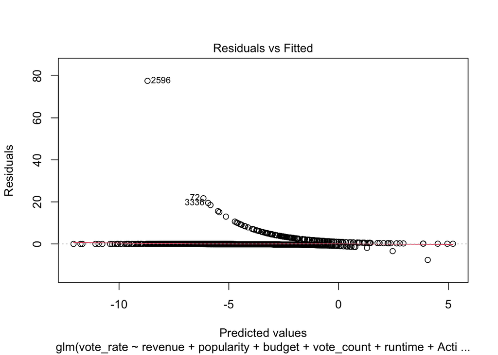

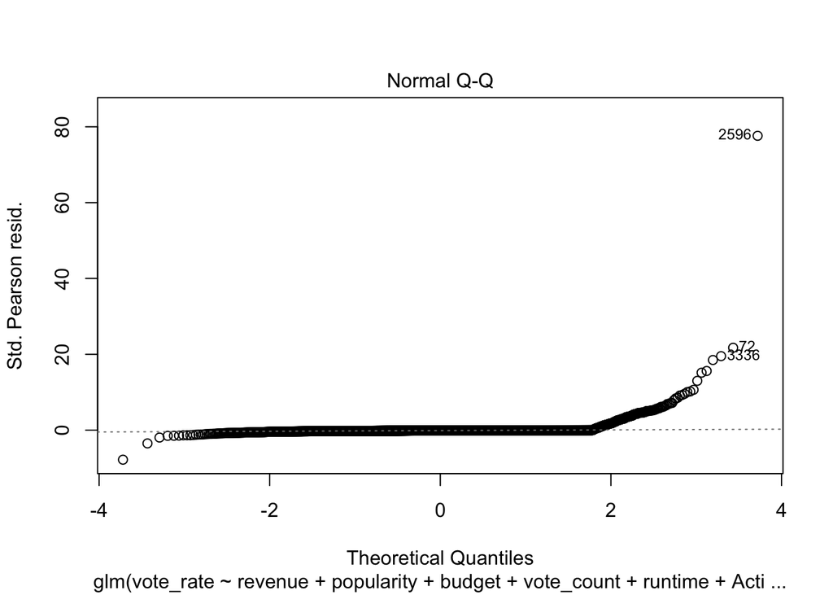

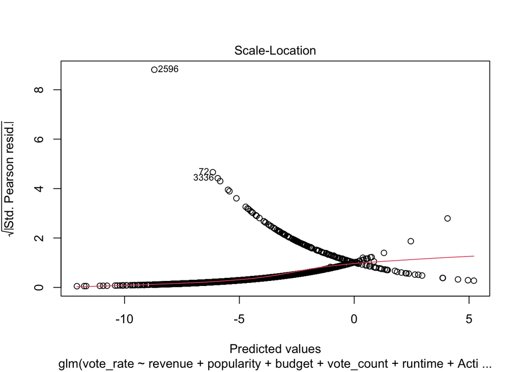

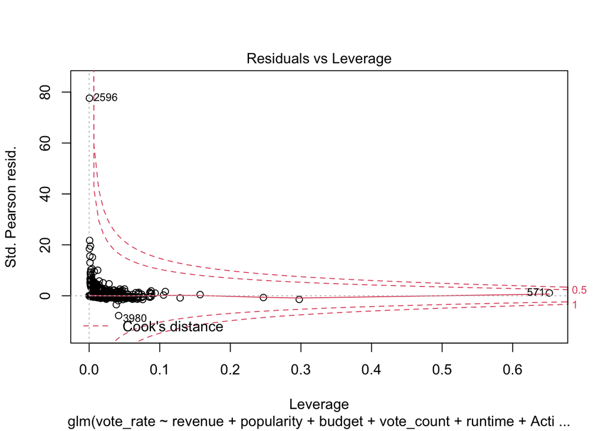

```r
plot(tmdb_glm)
```

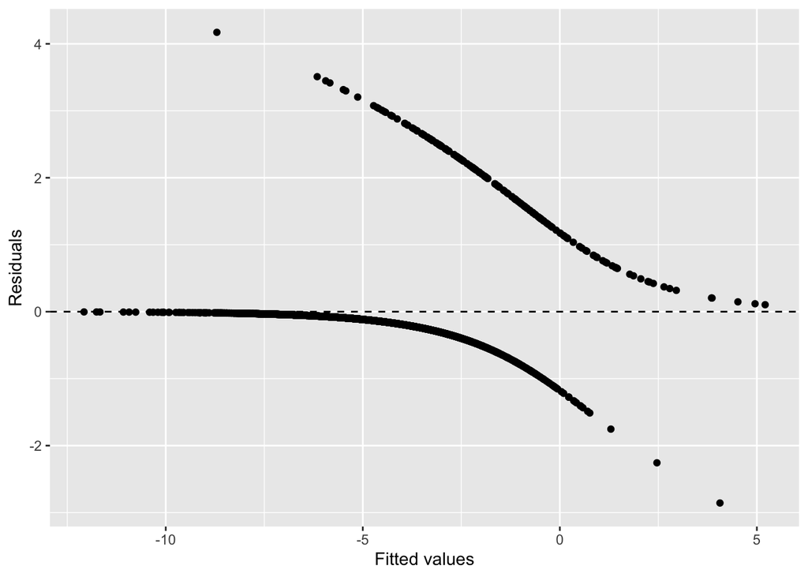

```r
ggplot(data = tmdb_glm, aes(x = .fitted, y = .resid)) +
  geom_point() +
  geom_hline(yintercept = 0, linetype = "dashed") +
  xlab("Fitted values") +
  ylab("Residuals")
```

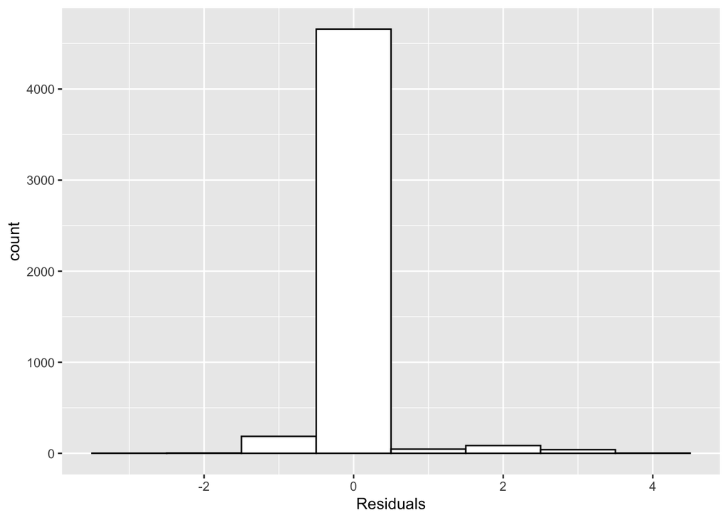

```r
#Showing the residuals
ggplot(data = tmdb_glm, aes(x = .resid)) +
  geom_histogram(binwidth = 1, fill='white', color='black') +
  xlab("Residuals")
```

```r
#Variance Importance
imp <- as.data.frame(varImp(tmdb_glm))
imp <- data.frame(overall = imp$Overall,
           names   = rownames(imp))
imp[order(imp$overall,decreasing = T),]
```

```
##        overall                 names
## 4  12.39147968            vote_count
## 5   7.73463091               runtime
## 3   6.93903676                budget
## 8   6.69000176         AnimationTRUE
## 2   4.92082480            popularity
## 11  4.40277402             DramaTRUE
## 15  3.07423320            HorrorTRUE
## 19  2.16211712 `Science Fiction`TRUE
## 21  2.12526408          ThrillerTRUE
## 23  1.80622806           WesternTRUE
## 16  1.73495816             MusicTRUE
## 18  1.20935860           RomanceTRUE
## 1   1.19053965               revenue
## 12  0.99535607            FamilyTRUE
## 20  0.94930738        `TV Movie`TRUE
## 13  0.94500305           FantasyTRUE
## 14  0.80551316           HistoryTRUE
## 7   0.65102696         AdventureTRUE
## 6   0.56807896            ActionTRUE
## 9   0.52869338            ComedyTRUE
## 22  0.46014464               WarTRUE
## 10  0.03669446             CrimeTRUE
## 17  0.02779991           MysteryTRUE
```

Based on the summary, we can see that the following factors play a big importance: popularity, budget, vote_count, runtime, Animation, Drama, Horror, Science Fiction, Thriller, and Western.

### First Model Confusion Matrix

Let’s have a look at this model’s evaluation first:

```r
# Predict probabilities on the testing set
glm_prob <- predict(tmdb_glm, testingset[,-1], type = "response")

# Create a vector to hold predictions
glm_predict <- rep(0,nrow(testingset[,-1]))
glm_predict[glm_prob >= 0.5] <- 1

# Create a confusion matrix
glm_confusion_matrix <- table(pred = glm_predict,
                             true = testingset$vote_rate)

glm_confusion_matrix
```

```
##     true
## pred    0    1
##    0 2054   70
##    1    8   20
```

### First Model Evaluation

```r
get_evaluation_measurements1 <- function(name = NA, tn, fp, fn, tp) {

  accuracy = (tp+tn)/(tp+tn+fp+fn)
  precision = tp/(tp+fp)
  recall = tp/(tp+fn)
  F1 = 2 * ((precision * recall)/(precision + recall))
  output = data.frame(name, accuracy, precision, recall, F1)
  return(output)
}

# Data frame the confusion matrix result and output the evaluation measures

glm_confusion_matrix_df <- as.data.frame(glm_confusion_matrix)

glm_evaluation_measures1 <- get_evaluation_measurements1("GLM1",
                                glm_confusion_matrix_df$Freq[1],
                                glm_confusion_matrix_df$Freq[2],
                                glm_confusion_matrix_df$Freq[3],
                                glm_confusion_matrix_df$Freq[4])

glm_evaluation_measures1
```

```
##   name  accuracy precision    recall        F1
## 1 GLM1 0.9637546 0.7142857 0.2222222 0.3389831
```

## Second GLM - less variables

```r
tmdb_glm2 = glm(formula = vote_rate ~ popularity + budget + vote_count + runtime + Animation + Drama + Horror + `Science Fiction` + Thriller + Western,
               data = trainingset,
               family = binomial(logit)
                 )
```

```r
summary(tmdb_glm2)
```

```
##
## Call:
## glm(formula = vote_rate ~ popularity + budget + vote_count +
##     runtime + Animation + Drama + Horror + `Science Fiction` +
##     Thriller + Western, family = binomial(logit), data = trainingset)
##
## Deviance Residuals:
##     Min       1Q   Median       3Q      Max
## -2.9660  -0.2495  -0.1383  -0.0719   3.8664
##
## Coefficients:
##                         Estimate Std. Error z value Pr(>|z|)
## (Intercept)           -7.594e+00  4.467e-01 -17.001  < 2e-16 ***
## popularity             2.551e-03  4.882e-04   5.225 1.75e-07 ***
## budget                -3.540e-08  3.896e-09  -9.085  < 2e-16 ***
## vote_count             3.940e-04  2.802e-05  14.060  < 2e-16 ***
## runtime                2.865e-02  3.471e-03   8.253  < 2e-16 ***
## AnimationTRUE          2.103e+00  2.814e-01   7.472 7.88e-14 ***
## DramaTRUE              1.231e+00  2.326e-01   5.291 1.21e-07 ***
## HorrorTRUE            -1.888e+00  6.413e-01  -2.944  0.00324 **
## `Science Fiction`TRUE -7.307e-01  3.349e-01  -2.182  0.02913 *
## ThrillerTRUE          -5.002e-01  2.362e-01  -2.117  0.03424 *
## WesternTRUE           -1.793e+00  1.010e+00  -1.776  0.07565 .
## ---
## Signif. codes:  0 '***' 0.001 '**' 0.01 '*' 0.05 '.' 0.1 ' ' 1
##
## (Dispersion parameter for binomial family taken to be 1)
##
##     Null deviance: 1584.5  on 5020  degrees of freedom
## Residual deviance: 1092.7  on 5010  degrees of freedom
## AIC: 1114.7
##
## Number of Fisher Scoring iterations: 8
```

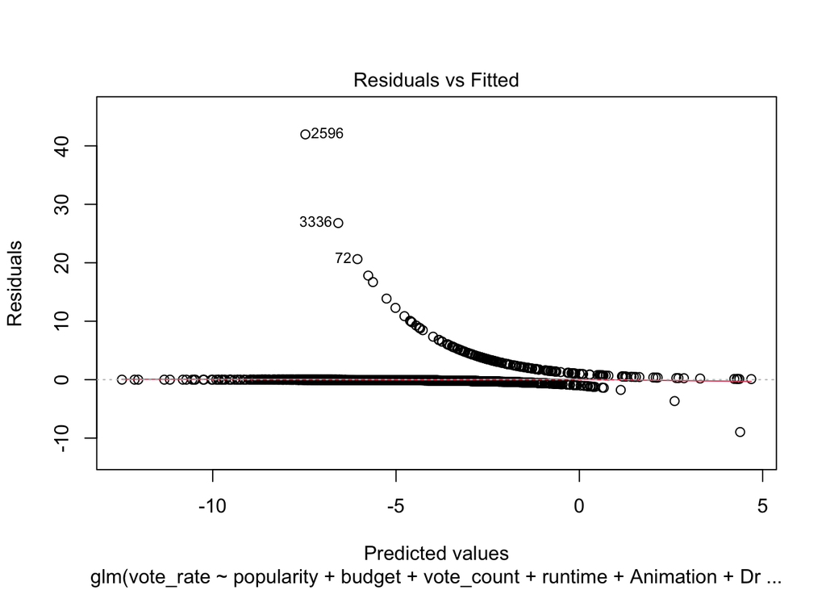

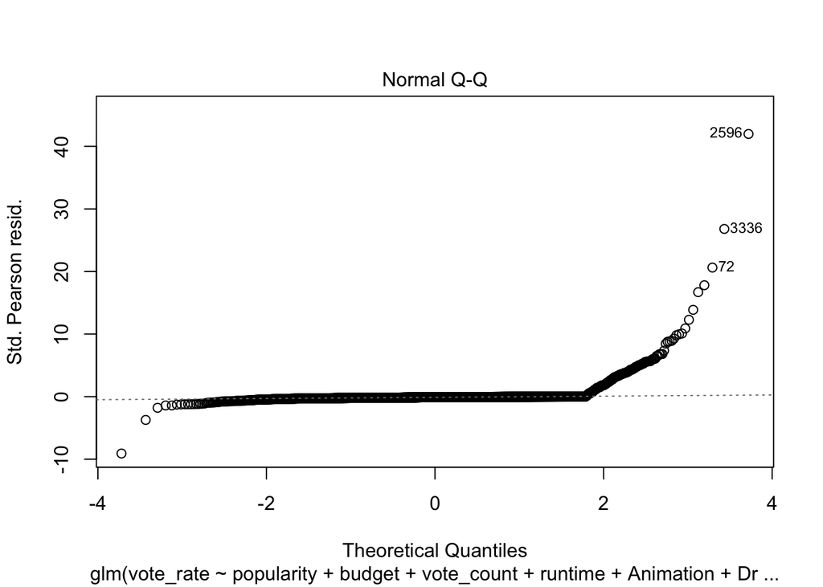

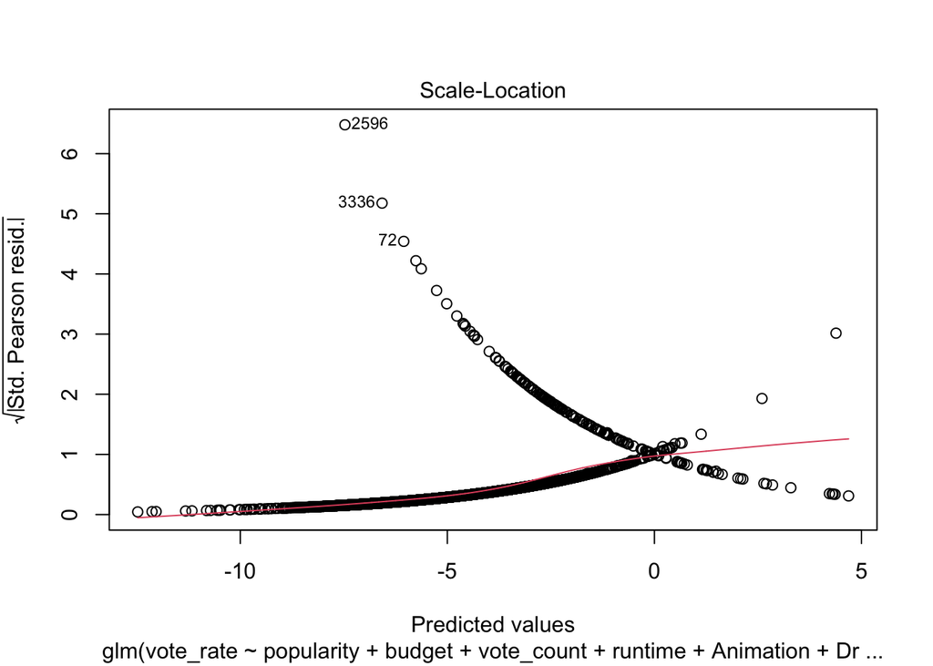

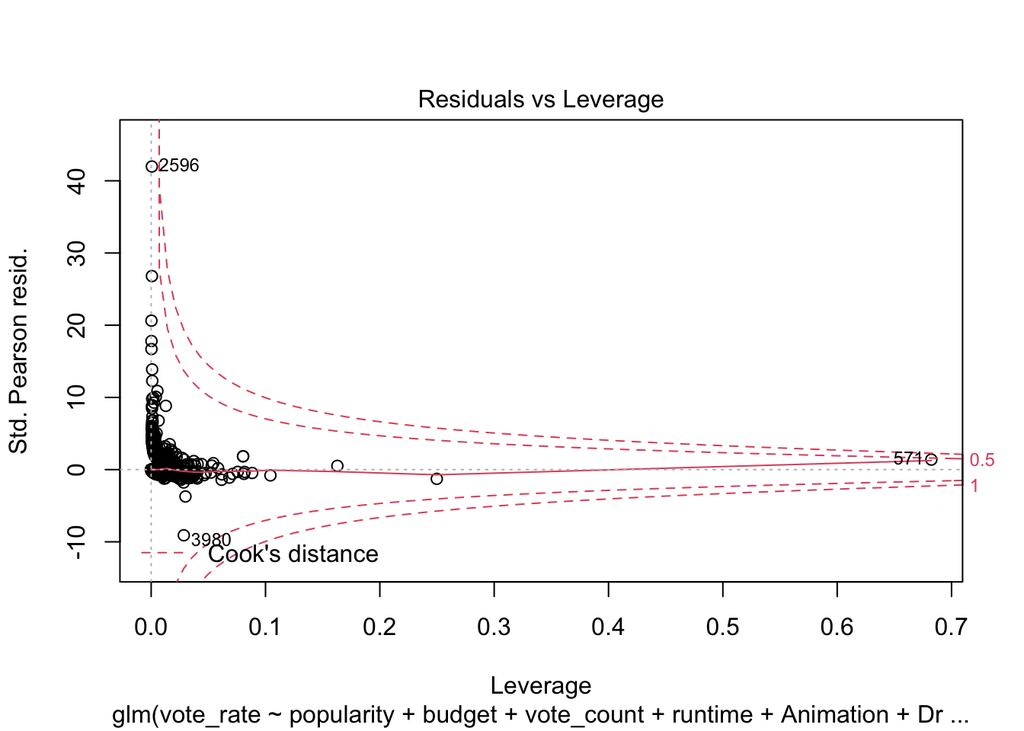

```r
plot(tmdb_glm2)
```

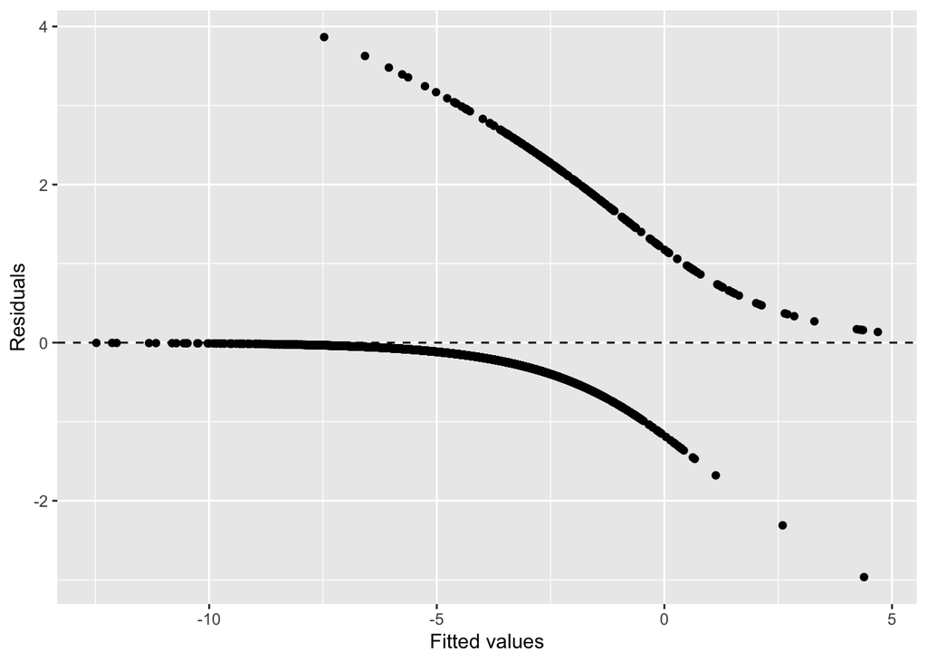

```r
ggplot(data = tmdb_glm2, aes(x = .fitted, y = .resid)) +
  geom_point() +
  geom_hline(yintercept = 0, linetype = "dashed") +
  xlab("Fitted values") +
  ylab("Residuals")
```

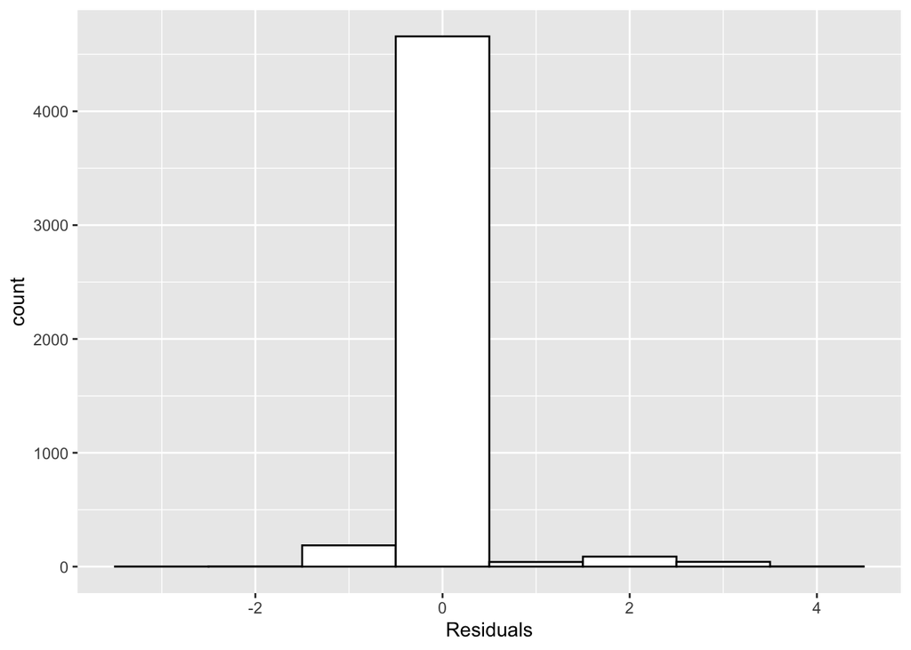

```r
#Showing the residuals
ggplot(data = tmdb_glm2, aes(x = .resid)) +
  geom_histogram(binwidth = 1, fill='white', color='black') +
  xlab("Residuals")
```

```r
#Variance Importance
imp2 <- as.data.frame(varImp(tmdb_glm2))
imp2 <- data.frame(overall = imp2$Overall,
           names   = rownames(imp2))
imp2[order(imp2$overall,decreasing = T),]
```

```
##      overall                 names
## 3  14.059626            vote_count
## 2   9.085185                budget
## 4   8.253337               runtime
## 5   7.472310         AnimationTRUE
## 6   5.291469             DramaTRUE
## 1   5.224589            popularity
## 7   2.943756            HorrorTRUE
## 8   2.181731 `Science Fiction`TRUE
## 9   2.117270          ThrillerTRUE
## 10  1.776478           WesternTRUE
```

### Second Model Confusion Matrix

Let’s have a look at the second model’s evaluation:

```r
# Predict probabilities on the test set
glm_prob2 <- predict(tmdb_glm2, testingset[,-1], type = "response")

# Create a vector to hold predictions
glm_predict2 <- rep(0,nrow(testingset[,-1]))
glm_predict2[glm_prob2 >= 0.5] <- 1

# Create a confusion matrix
glm_confusion_matrix2 <- table(pred = glm_predict2,
                             true = testingset$vote_rate)

glm_confusion_matrix2
```

```
##     true
## pred    0    1
##    0 2053   73
##    1    9   17
```

### Second Model Evaluations

```r
get_evaluation_measurements2 <- function(name = NA, tn, fp, fn, tp) {

  accuracy = (tp+tn)/(tp+tn+fp+fn)
  precision = tp/(tp+fp)
  recall = tp/(tp+fn)
  F1 = 2 * ((precision * recall)/(precision + recall))
  output2 = data.frame(name, accuracy, precision, recall, F1)
  return(output2)
}

# Data frame the confusion matrix result and output the evaluation measures

glm_confusion_matrix_df2 <- as.data.frame(glm_confusion_matrix2)

glm_evaluation_measures2 <- get_evaluation_measurements2("GLM2",
                              glm_confusion_matrix_df2$Freq[1],
                              glm_confusion_matrix_df2$Freq[2],
                              glm_confusion_matrix_df2$Freq[3],
                              glm_confusion_matrix_df2$Freq[4])

glm_evaluation_measures2
```

```
##   name  accuracy precision    recall        F1
## 1 GLM2 0.9618959 0.6538462 0.1888889 0.2931034
```

## Third GLM - even less variables

```r
tmdb_glm3 = glm(formula = vote_rate ~ popularity + budget + vote_count + runtime + Animation + Drama,
               data = trainingset,
               family = binomial(logit)
                 )
```

```r
summary(tmdb_glm3)
```

```
##
## Call:
## glm(formula = vote_rate ~ popularity + budget + vote_count +
##     runtime + Animation + Drama, family = binomial(logit), data = trainingset)
##
## Deviance Residuals:
##     Min       1Q   Median       3Q      Max
## -2.9922  -0.2490  -0.1487  -0.0938   3.6452
##
## Coefficients:
##                 Estimate Std. Error z value Pr(>|z|)
## (Intercept)   -8.121e+00  4.283e-01 -18.963  < 2e-16 ***
## popularity     2.492e-03  4.704e-04   5.297 1.18e-07 ***
## budget        -3.248e-08  3.686e-09  -8.813  < 2e-16 ***
## vote_count     3.696e-04  2.633e-05  14.036  < 2e-16 ***
## runtime        2.905e-02  3.359e-03   8.650  < 2e-16 ***
## AnimationTRUE  2.364e+00  2.700e-01   8.754  < 2e-16 ***
## DramaTRUE      1.486e+00  2.242e-01   6.626 3.45e-11 ***
## ---
## Signif. codes:  0 '***' 0.001 '**' 0.01 '*' 0.05 '.' 0.1 ' ' 1
##
## (Dispersion parameter for binomial family taken to be 1)
##
##     Null deviance: 1584.5  on 5020  degrees of freedom
## Residual deviance: 1123.9  on 5014  degrees of freedom
## AIC: 1137.9
##
## Number of Fisher Scoring iterations: 7
```

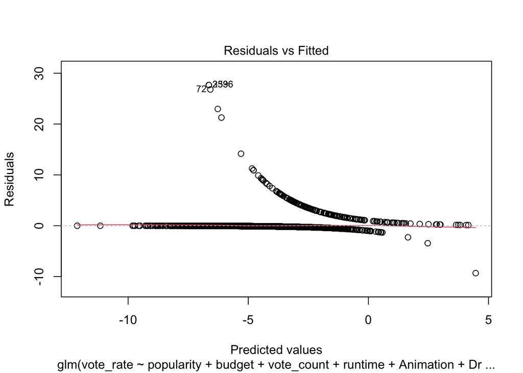

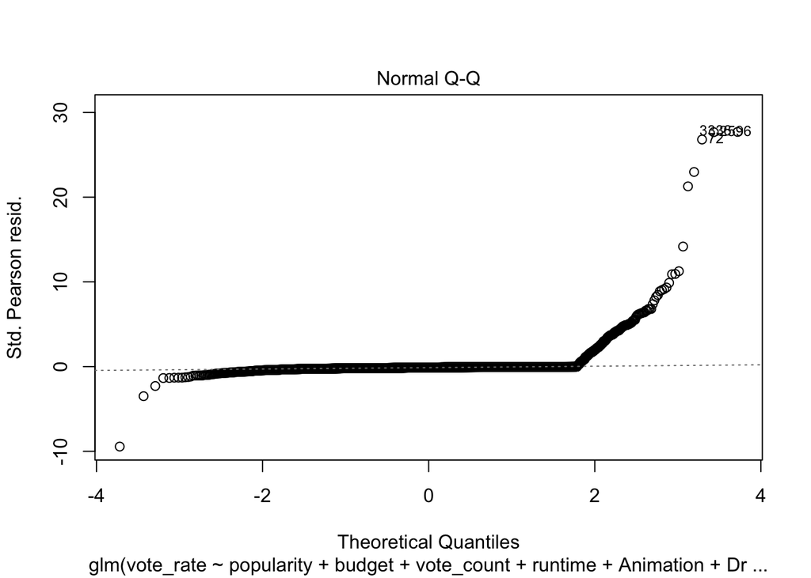

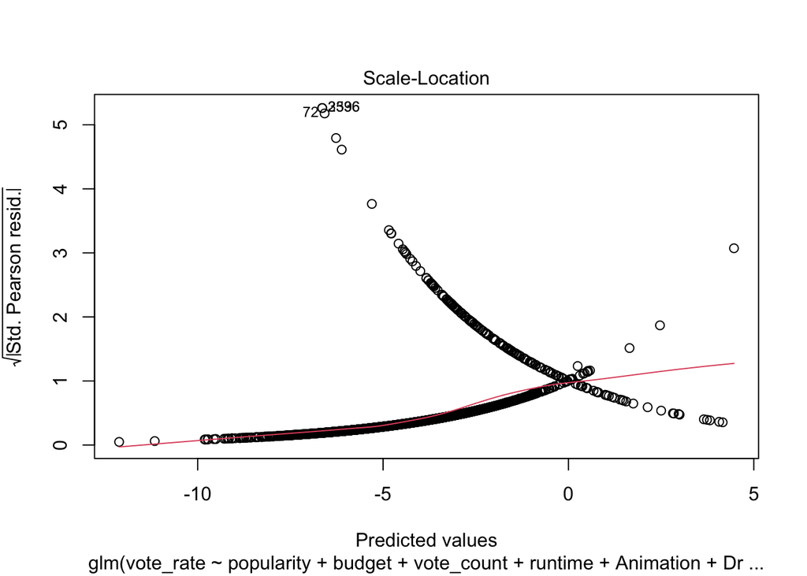

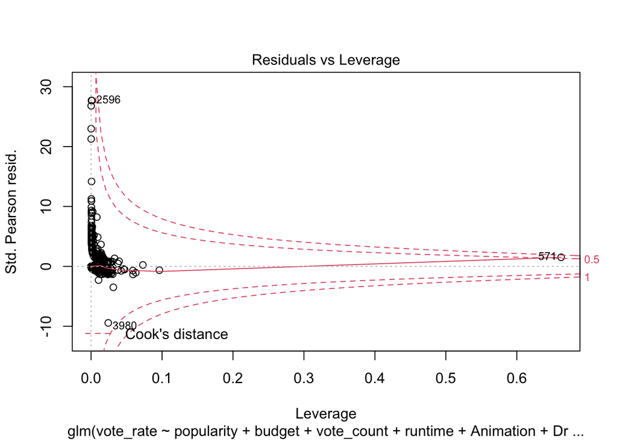

```r
plot(tmdb_glm3)
```

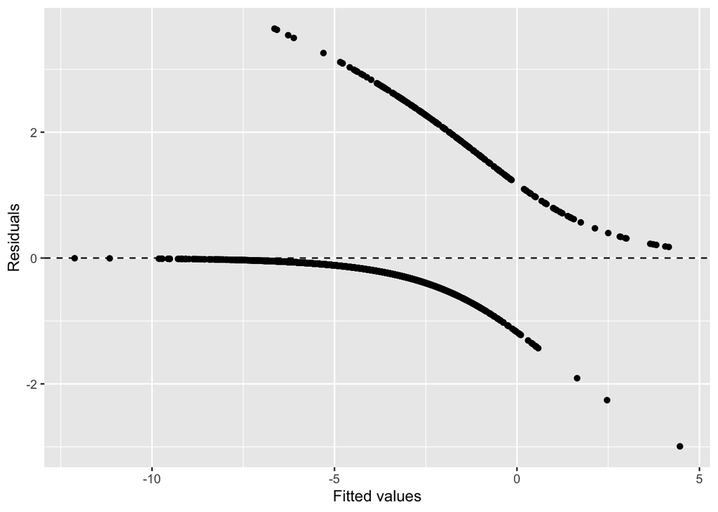

```r
ggplot(data = tmdb_glm3, aes(x = .fitted, y = .resid)) +
  geom_point() +
  geom_hline(yintercept = 0, linetype = "dashed") +
  xlab("Fitted values") +
  ylab("Residuals")
```

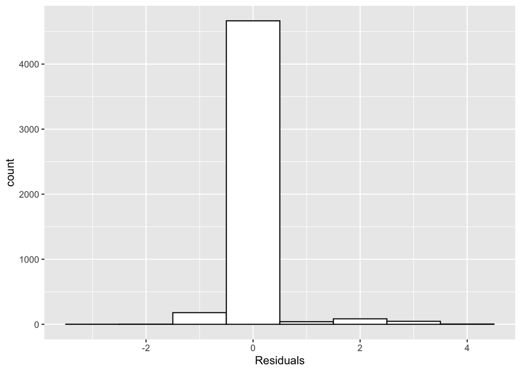

```r
#Showing the residuals
ggplot(data = tmdb_glm3, aes(x = .resid)) +
  geom_histogram(binwidth = 1, fill='white', color='black') +
  xlab("Residuals")
```

```r
#Variance Importance
imp3 <- as.data.frame(varImp(tmdb_glm3))
imp3 <- data.frame(overall = imp3$Overall,
           names   = rownames(imp3))
imp3[order(imp3$overall,decreasing = T),]
```

```
##     overall         names
## 3 14.035736    vote_count
## 2  8.812707        budget
## 5  8.754322 AnimationTRUE
## 4  8.649758       runtime
## 6  6.626076     DramaTRUE
## 1  5.296966    popularity
```

### Third Model Confusion Matrix

Let’s have a look at the third model’s evaluation:

```r
# Predict probabilities on the test set
glm_prob3 <- predict(tmdb_glm3, testingset[,-1], type = "response")

# Create a vector to hold predictions
glm_predict3 <- rep(0,nrow(testingset[,-1]))
glm_predict3[glm_prob3 >= 0.5] <- 1

# Create a confusion matrix
glm_confusion_matrix3 <- table(pred = glm_predict3,
                             true = testingset$vote_rate)

glm_confusion_matrix3
```

```
##     true
## pred    0    1
##    0 2055   72
##    1    7   18
```

### Third Model Evaluations

```r
get_evaluation_measurements3 <- function(name = NA, tn, fp, fn, tp) {

  accuracy = (tp+tn)/(tp+tn+fp+fn)
  precision = tp/(tp+fp)
  recall = tp/(tp+fn)
  F1 = 2 * ((precision * recall)/(precision + recall))
  output3 = data.frame(name, accuracy, precision, recall, F1)
  return(output3)
}

# Data frame the confusion matrix result and output the evaluation measures

glm_confusion_matrix_df3 <- as.data.frame(glm_confusion_matrix3)

glm_evaluation_measures3 <- get_evaluation_measurements3("GLM3",
                              glm_confusion_matrix_df3$Freq[1],
                              glm_confusion_matrix_df3$Freq[2],
                              glm_confusion_matrix_df3$Freq[3],
                              glm_confusion_matrix_df3$Freq[4])

glm_evaluation_measures3
```

```
##   name accuracy precision recall        F1
## 1 GLM3  0.96329      0.72    0.2 0.3130435
```

# Findings

- popularity, vote_count, runtime, Animation, and Drama, all of which has a positive influence on vote_rate
- budget, which has a negative influence on vote_rate, depicts that a larger budget does not automatically mean a movie will be of a highly rated.